# Day3: Diff-in-Diffとその応用

Jaehyun Song

8/29/2020

# パッケージとデータの読み込み

必要なパッケージとデータを読み込みます。差分の差分法を実装事態はR内蔵関数である`lm()`でできますが、データハンドリングと可視化のために`tidyverse`を、記述統計の出力のために`summarytools`パッケージを読み込みます。また、頑健な標準誤差（robust standard error）計算と出力のためには、`multiwayvcov`と`lmtest`が必要です。インストール済みでない方は`install.packages()`や`pacman::p_load()`でインストールしておきましょう[^1]。

必要なデータは講義用Slackで配布している`EnglishBacon.csv`です。[Harvard Dataverse](https://dataverse.harvard.edu/dataset.xhtml?persistentId=doi:10.7910/DVN/29427)からもダウンロード可能ですが、こちらはクリーニングが必要です。本講義はRの使い方に関する講義ではないため、ここではクリーニング済みのでデータを使用します。

```r
# Thanks, Hadley!
library(tidyverse)
library(summarytools)
library(multiwayvcov) # 頑健な標準誤差計算のためのパッケージ
library(lmtest)       # 頑健な標準誤差計算のためのパッケージ

# Load dataset
Bacon.df <- read_csv("Day3_Data5.csv")
```

# 記述統計量の確認と変数のクリーニング

まずは、データのサイズを確認します。

```r
dim(Bacon.df)
```

```
## [1] 8059   15
```

データの大きさは8059行15列です。それでは15個の変数名を`names()`関数を使って出力します。これはデータフレームの列名を出力する関数です。

```r
names(Bacon.df)
```

```
##  [1] "Assembly" "Year"     "Treat"    "FG"       "y_0"      "y_m1"
##  [7] "y_m2"     "y_m3"     "y_m4"     "y_m5"     "y_p1"     "y_p2"
## [13] "y_p3"     "y_p4"     "y_p5"
```

それぞれの変数の詳細はFouirnaies and Mutlu-Eren (2015)[^2]を参照して頂きたいところですが、こちらでも簡単に説明しておきます。

| 変数名 | 説明 |
| --- | --- |
| `Assembly` | 地方議会名 |
| `Year` | 年 |
| `Treat` | 地方議会の多数派と政府与党の一致有無 |
| `FG` | t期の一人あたり定式補助金（対数） |
| `y_0` | t期の一人あたり特定補助金額（対数） |
| `y_m*` | t - *期の一人あたり特定補助金額（対数） |
| `y_p*` | t + *期の一人あたり特定補助金額（対数） |

データの記述統計量を出力します。

```r
# 記述統計量を確認
view(dfSummary(Bacon.df))
```

| **No** | **Variable** | **Stats / Values** | **Freqs (% of Valid)** | **Graph** | **Valid** | **Missing** |
| --- | --- | --- | --- | --- | --- | --- |
| 1 | Assembly [character] | 1. DURHAM 2. ADUR 3. ALLERDALE 4. AMBER VALLEY 5. ARUN 6. ASHFIELD 7. ASHFORD 8. AYLESBURY VALE 9. BABERGH 10. BARKING & DAGENHAM [ 411 others ] | 38 ( 0.5% ) 21 ( 0.3% ) 21 ( 0.3% ) 21 ( 0.3% ) 21 ( 0.3% ) 21 ( 0.3% ) 21 ( 0.3% ) 21 ( 0.3% ) 21 ( 0.3% ) 21 ( 0.3% ) 7832 ( 97.2% ) |  | 8059 (100%) | 0 (0%) |
| 2 | Year [numeric] | Mean (sd) : 2001.8 (6) min < med < max: 1992 < 2002 < 2012 IQR (CV) : 10 (0) | 21 distinct values |  | 8059 (100%) | 0 (0%) |
| 3 | Treat [numeric] | Min : 0 Mean : 0.3 Max : 1 | 0 : 5618 ( 72.4% ) 1 : 2140 ( 27.6% ) |  | 7758 (96.27%) | 301 (3.73%) |
| 4 | FG [numeric] | Mean (sd) : 16.9 (1.6) min < med < max: 13.9 < 16 < 20.9 IQR (CV) : 3 (0.1) | 6936 distinct values |  | 8059 (100%) | 0 (0%) |
| 5 | y_0 [numeric] | Mean (sd) : 2.7 (2.1) min < med < max: -2.4 < 2.3 < 7.7 IQR (CV) : 3.2 (0.8) | 7813 distinct values |  | 7993 (99.18%) | 66 (0.82%) |
| 6 | y_m1 [numeric] | Mean (sd) : 2.7 (2) min < med < max: -2.4 < 2.2 < 7.7 IQR (CV) : 3.2 (0.8) | 7362 distinct values |  | 7533 (93.47%) | 526 (6.53%) |
| 7 | y_m2 [numeric] | Mean (sd) : 2.6 (2) min < med < max: -2.4 < 2.1 < 7.7 IQR (CV) : 3.1 (0.8) | 6909 distinct values |  | 7075 (87.79%) | 984 (12.21%) |
| 8 | y_m3 [numeric] | Mean (sd) : 2.5 (2) min < med < max: -2.4 < 2 < 7.4 IQR (CV) : 3.1 (0.8) | 6454 distinct values |  | 6615 (82.08%) | 1444 (17.92%) |
| 9 | y_m4 [numeric] | Mean (sd) : 2.4 (1.9) min < med < max: -2.4 < 1.9 < 7.3 IQR (CV) : 3.1 (0.8) | 6006 distinct values |  | 6160 (76.44%) | 1899 (23.56%) |
| 10 | y_m5 [numeric] | Mean (sd) : 2.4 (1.9) min < med < max: -2.4 < 1.7 < 7.3 IQR (CV) : 3 (0.8) | 5584 distinct values |  | 5735 (71.16%) | 2324 (28.84%) |
| 11 | y_p1 [numeric] | Mean (sd) : 2.8 (2.1) min < med < max: -2.4 < 2.3 < 7.7 IQR (CV) : 3.3 (0.7) | 7397 distinct values |  | 7561 (93.82%) | 498 (6.18%) |
| 12 | y_p2 [numeric] | Mean (sd) : 2.9 (2.1) min < med < max: -2.4 < 2.3 < 7.7 IQR (CV) : 3.4 (0.7) | 6962 distinct values |  | 7108 (88.2%) | 951 (11.8%) |
| 13 | y_p3 [numeric] | Mean (sd) : 2.9 (2.1) min < med < max: -2.4 < 2.4 < 7.7 IQR (CV) : 3.5 (0.7) | 6522 distinct values |  | 6649 (82.5%) | 1410 (17.5%) |
| 14 | y_p4 [numeric] | Mean (sd) : 3 (2.1) min < med < max: -1 < 2.4 < 7.7 IQR (CV) : 3.6 (0.7) | 6104 distinct values |  | 6209 (77.04%) | 1850 (22.96%) |
| 15 | y_p5 [numeric] | Mean (sd) : 3.1 (2.1) min < med < max: -1 < 2.4 < 7.7 IQR (CV) : 3.6 (0.7) | 5707 distinct values |  | 5783 (71.76%) | 2276 (28.24%) |

Generated by summarytools 0.9.6 ([R](https://www.r-project.org/) version 4.0.2)  
2020-09-07

`Year`変数は連続変数ではなく、離散変数として利用する予定なので、integer型からfactor型へ変換します。また、後ほどトレンド変数も使いますのでトレンド変数も作成します。1992年を1、1993年を2、…にしたいので、`Year`変数から1991を引けばいいです。

`Year`をfactor型にしたら引き算ができなくなるので、トレンド変数を作成し、続いて`Year`変数をfactor型にします。

```r
Bacon.df <- Bacon.df %>%
    mutate(Trend = Year - 1991,
           Year  = factor(Year))
```

# 線形トレンドを無視したDID推定

まずは、線形トレンドを考慮しない差分の差分法を行います。やり方としては、説明変数として、処置変数とユニット[^3]のダミー変数、年度のダミー変数を投入します。記述統計で見られるように、`Assembly`と`Year`はfactor型になっているため、このまま入れてたらダミー変数化した上で分析をやってくれます。

結果変数 (応答変数)は、$t+1$年の当該自治体への特定補助金 (一人あたり; 対数)から定式補助金です。ただし、同じ党派性を持つという処置から起因する補助金の増額が$t+1$年から見られるとは限りません。したがって、$t+2$から$t+5$年までの補助金も説明変数として使いましょう。

まずは特定補助金（`y_`で始まる変数）から定式補助金(`FG`)を引きましょう。

```r
Bacon.df <- Bacon.df %>%
    mutate(y_0  = y_0  - FG, # y_0からy_m5は後で使います。
           y_m1 = y_m1 - FG, # 今のうちに引いておきます。
           y_m2 = y_m2 - FG,
           y_m3 = y_m3 - FG,
           y_m4 = y_m4 - FG,
           y_m5 = y_m5 - FG,
           y_p1 = y_p1 - FG,
           y_p2 = y_p2 - FG,
           y_p3 = y_p3 - FG,
           y_p4 = y_p4 - FG,
           y_p5 = y_p5 - FG)
```

それでは`y_p1`から`y_p5`までを結果変数とした差分の差分推定を行います。`y_0`を結果変数として使わない理由は単純です。議会と政府の党派性が一致した時点での補助金額は既に決まっているからです。補助金額に変動があるとすれば、次の年からだと考えた方が自然でしょう。

推定に投入する変数は処置変数に加え、議会と年とダミー変数となります。

```r
# Model 1: Diff-in-Diff Estimation without linear trends
Bacon.Fit1.P1 <- lm(y_p1 ~ Treat + Assembly + Year,
                    data = Bacon.df)
Bacon.Fit1.P2 <- lm(y_p2 ~ Treat + Assembly + Year,
                    data = Bacon.df)
Bacon.Fit1.P3 <- lm(y_p3 ~ Treat + Assembly + Year,
                    data = Bacon.df)
Bacon.Fit1.P4 <- lm(y_p4 ~ Treat + Assembly + Year,
                    data = Bacon.df)
Bacon.Fit1.P5 <- lm(y_p5 ~ Treat + Assembly + Year,
                    data = Bacon.df)
```

5つの推定結果を一つのリスト変数に格納します。List型は「なんでも」入れることが可能なデータ型です[^4]。代表的なデータ型であるベクトル、行列、データフレームはもちろん、`lm()`関数から得られた`lm`型データも格納できます。

```r
Bacon1.List <- list(Bacon.Fit1.P1,
                    Bacon.Fit1.P2,
                    Bacon.Fit1.P3,
                    Bacon.Fit1.P4,
                    Bacon.Fit1.P5)
```

可視化のためのデータフレームを作成します[^5]。1列目は結果変数の説明、`Coef`列には係数が、`SE`列には標準誤差を入れます。

```r
Fit1.Coef <- data.frame(
    Model = c("t+1", "t+2", "t+3", "t+4", "t+5"),
    Coef  = NA,
    SE    = NA
)
```

議会ごとにクラスタリングした頑健標準誤差を計算します。そのためには`multiwayvcov`パッケージにある`cluster.vocv()`関数を使います。具体的には`cluster.vcov(回帰分析オブジェクト, ~ クラスタリングする変数)`です。

回帰分析の結果はリストに格納されています。リスト型から要素を抽出する方法は`リスト名[[i]]`です。リストから`i`番目の要素を抽出する方法です。`Bacon1.List`の一番目の要素は`Bacon.Fit1.P1`です。つまり、`Bacon1.List[[1]]`は`Bacon.Fit1.P1`と同じです。これは`for()`関数を用いた反復作業に有効です。

`cluster.vcov()`からは分散共分散行列が得られます。`coeftest(回帰分析オブジェクト, 分散共分散行列オブジェクト)`で頑健標準誤差が計算できます。

`for()`による反復作業を行う前に簡単に`cluster.vocv()`と`coeftest()`の挙動を確認します。`Bacon1.List`の最初の要素、つまり`Bacon.Fit1.P1`の頑健な標準誤差を計算します。まずは、分散共分散行列を計算します。ここでは議会（`Assembly`）単位でクラスター標準誤差を計算するため、`cluster.vcov()`関数を使い、第一引数としては回帰分析のオブジェクト、第荷引数として`~ Assembly`をしてします。

```r
Fit1_VCOV <- cluster.vcov(Bacon1.List[[1]], ~ Assembly)
```

得られた結果のクラスを確認すると、行列が得られたことが分かります。

```r
class(Fit1_VCOV)
```

```
## [1] "matrix" "array"
```

行列の大きさな$420 \times 420$、つまり420行420列の正方行列ということが分かります。切片を含む推定パラメーターは420個なので、420行/列になります。

```r
dim(Fit1_VCOV)
```

```
## [1] 420 420
```

最後に回帰表として出力します。`lmtest::coeftest()`を使用し、第一引数としては回帰分析のオブジェクト、第二引数として先ほど得られた分散共分散行列のオブジェクトを指定します。420行の表が出力されるため、最初の6行のみ出力します。

```r
Fit1_Table <- coeftest(Bacon1.List[[1]], Fit1_VCOV)

head(Fit1_Table)
```

```
##                          Estimate  Std. Error     t value  Pr(>|t|)
## (Intercept)          -16.19977976 0.044994062 -360.042618 0.0000000
## Treat                  0.02153703 0.027840913    0.773575 0.4392088
## AssemblyALLERDALE     -0.34229069 0.005563460  -61.524787 0.0000000
## AssemblyALNWICK        0.85889039 0.008752683   98.128816 0.0000000
## AssemblyAMBER VALLEY  -0.33513639 0.004244898  -78.950404 0.0000000
## AssemblyARUN          -0.78121846 0.005861245 -133.285420 0.0000000
```

クラスター標準誤差を使わなかった場合の推定結果も見てみましょう。`summary(回帰分析オブジェクト)$coef`からパラメーターの点推定値および標準誤差などが得られます。こちらも最初の6行だけ出力します。

```r
summary(Bacon1.List[[1]])$coef %>%
  head()
```

```
##                          Estimate Std. Error     t value     Pr(>|t|)
## (Intercept)          -16.19977976 0.13482476 -120.154334 0.000000e+00
## Treat                  0.02153703 0.01885381    1.142317 2.533620e-01
## AssemblyALLERDALE     -0.34229069 0.18356939   -1.864639 6.227461e-02
## AssemblyALNWICK        0.85889039 0.19792493    4.339475 1.448699e-05
## AssemblyAMBER VALLEY  -0.33513639 0.18355257   -1.825833 6.791878e-02
## AssemblyARUN          -0.78121846 0.18590451   -4.202257 2.676157e-05
```

それでは、以上の作業を反復構文（`for()`関数）を使って自動化します。

```r
for (i in 1:5) {
    Temp.VCOV <- cluster.vcov(Bacon1.List[[i]], ~ Assembly)
    Temp.Coef <- coeftest(Bacon1.List[[i]], Temp.VCOV)

    # Temp.Coefの2行目がTreat変数の行
    # 1, 2番目列は係数と標準誤差が格納されている。
    Fit1.Coef[i, 2:3] <- Temp.Coef[2, 1:2]
}
```

```r
Fit1.Coef
```

```
##   Model       Coef         SE
## 1   t+1 0.02153703 0.02784091
## 2   t+2 0.07146649 0.02732057
## 3   t+3 0.11864721 0.02781304
## 4   t+4 0.10605010 0.02564138
## 5   t+5 0.06766683 0.02211213
```

これで各回帰モデルにおけるDID推定量とその標準誤差が一つのテーブルとしてまとまりました。続いて、95%信頼区間を算出し、下限と上限をそれぞれ`LL`と`UL`という列に格納します。

```r
Fit1.Coef <- Fit1.Coef %>%
    mutate(LL  = Coef - 1.96 * SE,
           UL  = Coef + 1.96 * SE,
           Sig = if_else(LL * UL > 0, "Significant", "Insignificant"))

# 中身を確認
Fit1.Coef
```

```
##   Model       Coef         SE          LL         UL           Sig
## 1   t+1 0.02153703 0.02784091 -0.03303116 0.07610522 Insignificant
## 2   t+2 0.07146649 0.02732057  0.01791818 0.12501481   Significant
## 3   t+3 0.11864721 0.02781304  0.06413365 0.17316078   Significant
## 4   t+4 0.10605010 0.02564138  0.05579299 0.15630721   Significant
## 5   t+5 0.06766683 0.02211213  0.02432706 0.11100660   Significant
```

作図の時間です！

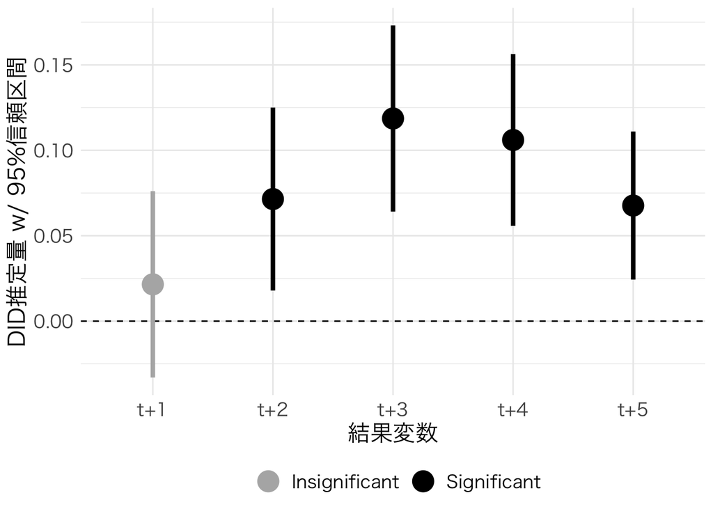

```r
Fit1.Coef %>%
  ggplot() +
  # y = 0の水平線 (破線)
  geom_hline(yintercept = 0, linetype = 2) +
  # 各モデルの点推定値と信頼区間を出力
  # Sigの値によって色分け
  geom_pointrange(aes(x = Model, y = Coef, ymin = LL, ymax = UL,
                      color = Sig),
                  size = 1.5) +
  # 軸ラベルを設定
  labs(x = "結果変数", y = "DID推定量 w/ 95%信頼区間", color = "") +
  # 色分けを手動で調整
  scale_color_manual(values = c("Significant"   = "black",
                                "Insignificant" = "gray70")) +
  # 日本語フォントの指定
  theme_minimal(base_family = "HiraKakuProN-W3") +
  # 文字サイズ、凡例位置調整
  theme(text = element_text(size = 16),
        legend.position = "bottom")
```

# 線形トレンドを考慮したDID推定

これまでのやり方と同じです。ただし、今回はトレンドを表す変数として`Trend`が投入されます。この`Trend`は単体で投入されるのではなく、ユニットのダミー変数である`Assembly`との交差項で投入します。また、本稿はトレンドが2次曲線であると仮定し、トレンド変数の二乗項を投入しています。ここでも`I(Trend^2)`で対応しましょう[^6]。

2つの変数を`*`で繋いだらそれぞれの変数と交差項が同時に投入されますが、`:`で繋ぐと交差校のみが投入されます。

```r
# Model 2: Diff-in-Diff Estimation with linear trends
Bacon.Fit2.P1 <- lm(y_p1  ~ Treat + Assembly + Year +
                        Assembly:I(Trend^2), data = Bacon.df)
Bacon.Fit2.P2 <- lm(y_p2  ~ Treat + Assembly + Year +
                        Assembly:I(Trend^2), data = Bacon.df)
Bacon.Fit2.P3 <- lm(y_p3  ~ Treat + Assembly + Year +
                        Assembly:I(Trend^2), data = Bacon.df)
Bacon.Fit2.P4 <- lm(y_p4  ~ Treat + Assembly + Year +
                        Assembly:I(Trend^2), data = Bacon.df)
Bacon.Fit2.P5 <- lm(y_p5  ~ Treat + Assembly + Year +
                        Assembly:I(Trend^2), data = Bacon.df)
```

以下の作業は線形トレンドを仮定しなかったモデルの可視化と同じ手順となります。

```r
Bacon2.List <- list(Bacon.Fit2.P1,
                    Bacon.Fit2.P2,
                    Bacon.Fit2.P3,
                    Bacon.Fit2.P4,
                    Bacon.Fit2.P5)
```

```r
Fit2.Coef <- data.frame(
    Model = c("t+1", "t+2", "t+3", "t+4", "t+5"),
    Coef  = NA,
    SE    = NA
)
```

```r
for (i in 1:5) {
    Temp.VCOV <- cluster.vcov(Bacon2.List[[i]], ~ Assembly)
    Temp.Coef <- coeftest(Bacon2.List[[i]], Temp.VCOV)

    Fit2.Coef[i, 2:3] <- Temp.Coef[2, 1:2]
}
Fit2.Coef
```

```
##   Model       Coef         SE
## 1   t+1 0.04887276 0.02325289
## 2   t+2 0.05332587 0.02413514
## 3   t+3 0.06167312 0.02542695
## 4   t+4 0.05217814 0.02496539
## 5   t+5 0.02613562 0.02375921
```

```r
Fit2.Coef <- Fit2.Coef %>%
    mutate(LL  = Coef - 1.96 * SE,
           UL  = Coef + 1.96 * SE,
           Sig = if_else(LL * UL > 0, "Significant", "Insignificant"))

# 中身を確認
Fit2.Coef
```

```
##   Model       Coef         SE           LL         UL           Sig
## 1   t+1 0.04887276 0.02325289  0.003297094 0.09444842   Significant
## 2   t+2 0.05332587 0.02413514  0.006020987 0.10063075   Significant
## 3   t+3 0.06167312 0.02542695  0.011836300 0.11150993   Significant
## 4   t+4 0.05217814 0.02496539  0.003245985 0.10111030   Significant
## 5   t+5 0.02613562 0.02375921 -0.020432441 0.07270368 Insignificant
```

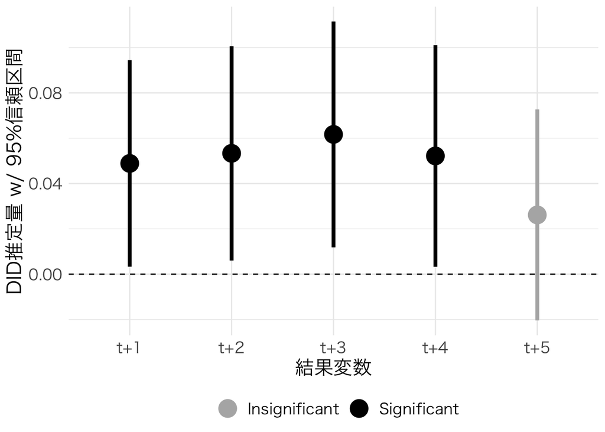

```r
Fit2.Coef %>%
  ggplot() +
  # y = 0の水平線 (破線)
  geom_hline(yintercept = 0, linetype = 2) +
  # 各モデルの点推定値と信頼区間を出力
  # Sigの値によって色分け
  geom_pointrange(aes(x = Model, y = Coef, ymin = LL, ymax = UL,
                      color = Sig),
                  size = 1.5) +
  # 軸ラベルを設定
  labs(x = "結果変数", y = "DID推定量 w/ 95%信頼区間", color = "") +
  # 色分けを手動で調整
  scale_color_manual(values = c("Significant"   = "black",
                                "Insignificant" = "gray70")) +
  # 日本語フォントの指定
  theme_minimal(base_family = "HiraKakuProN-W3") +
  # 文字サイズ、凡例位置調整
  theme(text = element_text(size = 16),
        legend.position = "bottom")
```

# 頑健性の確認

頑健性のチェックは様々な方法が考えられますが、今回は本稿の著者たちが行った方法で確認してみます。それは$t$年や$t-1$なども結果変数として用いることです。もし、処置によって*過去の*補助金額が増額されたら、$t+1$期以降に見られる補助金増額は処置による効果とは言いにくくなりますね。

$t$年の補助金額は`y_0`、$t-1$年のそれは`y_m1`です。今回はトレンド変数 (の二乗項)ありのモデルを使います。

```r
Bacon.Fit2.M5 <- lm(y_m5  ~ Treat + Assembly + Year +
                        Assembly:I(Trend^2), data = Bacon.df)
Bacon.Fit2.M4 <- lm(y_m4  ~ Treat + Assembly + Year +
                        Assembly:I(Trend^2), data = Bacon.df)
Bacon.Fit2.M3 <- lm(y_m3  ~ Treat + Assembly + Year +
                        Assembly:I(Trend^2), data = Bacon.df)
Bacon.Fit2.M2 <- lm(y_m2  ~ Treat + Assembly + Year +
                        Assembly:I(Trend^2), data = Bacon.df)
Bacon.Fit2.M1 <- lm(y_m1  ~ Treat + Assembly + Year +
                        Assembly:I(Trend^2), data = Bacon.df)
Bacon.Fit2.0  <- lm(y_0   ~ Treat + Assembly + Year +
                        Assembly:I(Trend^2), data = Bacon.df)
```

```r
Bacon2.List2 <- list(Bacon.Fit2.M5,
                     Bacon.Fit2.M4,
                     Bacon.Fit2.M3,
                     Bacon.Fit2.M2,
                     Bacon.Fit2.M1,
                     Bacon.Fit2.0)
```

```r
Fit2.Coef2 <- data.frame(
    Model = c("t-5", "t-4", "t-3", "t-2", "t-1", "t"),
    Coef  = NA,
    SE    = NA
)
```

```r
for (i in 1:6) {
    Temp.VCOV <- cluster.vcov(Bacon2.List2[[i]], ~ Assembly)
    Temp.Coef <- coeftest(Bacon2.List2[[i]], Temp.VCOV)

    Fit2.Coef2[i, 2:3] <- Temp.Coef[2, 1:2]
}
Fit2.Coef2
```

```
##   Model         Coef         SE
## 1   t-5  0.022467223 0.02353598
## 2   t-4 -0.028591324 0.02122114
## 3   t-3 -0.002882570 0.02161793
## 4   t-2  0.008561009 0.01852903
## 5   t-1  0.031119494 0.01834984
## 6     t  0.039339556 0.02349816
```

```r
Fit2.Coef2 <- Fit2.Coef2 %>%
    mutate(LL  = Coef - 1.96 * SE,
           UL  = Coef + 1.96 * SE,
           Sig = if_else(LL * UL > 0, "Significant", "Insignificant"))

# 中身を確認
Fit2.Coef2
```

```
##   Model         Coef         SE           LL         UL           Sig
## 1   t-5  0.022467223 0.02353598 -0.023663288 0.06859773 Insignificant
## 2   t-4 -0.028591324 0.02122114 -0.070184766 0.01300212 Insignificant
## 3   t-3 -0.002882570 0.02161793 -0.045253715 0.03948857 Insignificant
## 4   t-2  0.008561009 0.01852903 -0.027755882 0.04487790 Insignificant
## 5   t-1  0.031119494 0.01834984 -0.004846198 0.06708519 Insignificant
## 6     t  0.039339556 0.02349816 -0.006716843 0.08539595 Insignificant
```

このまま可視化も有りですが、せっかくなのでこれまでの推定結果と一緒に表示させましょう。2つのデータフレームを上下に結合する関数は`bind_rows()`です。これを使う場合、2つのデータフレームの列名を一致する必要があります。

```r
Robust.Coef <- bind_rows(Fit2.Coef2, Fit2.Coef)

# Robust.Coefの中身をチェック
print(Robust.Coef, digits = 3)
```

```
##    Model     Coef     SE       LL     UL           Sig
## 1    t-5  0.02247 0.0235 -0.02366 0.0686 Insignificant
## 2    t-4 -0.02859 0.0212 -0.07018 0.0130 Insignificant
## 3    t-3 -0.00288 0.0216 -0.04525 0.0395 Insignificant
## 4    t-2  0.00856 0.0185 -0.02776 0.0449 Insignificant
## 5    t-1  0.03112 0.0183 -0.00485 0.0671 Insignificant
## 6      t  0.03934 0.0235 -0.00672 0.0854 Insignificant
## 7    t+1  0.04887 0.0233  0.00330 0.0944   Significant
## 8    t+2  0.05333 0.0241  0.00602 0.1006   Significant
## 9    t+3  0.06167 0.0254  0.01184 0.1115   Significant
## 10   t+4  0.05218 0.0250  0.00325 0.1011   Significant
## 11   t+5  0.02614 0.0238 -0.02043 0.0727 Insignificant
```

また、できれば可視化の際、横軸を$t-5$から$t+5$の順で並べたいので、`Model`列を順序付きのfactor型にします。

```r
Robust.Coef <- Robust.Coef %>%
    mutate(Model = factor(Model, ordered = TRUE,
                          levels = c("t-5", "t-4", "t-3",
                                     "t-2", "t-1", "t",
                                     "t+1", "t+2", "t+3",
                                     "t+4", "t+5")))
```

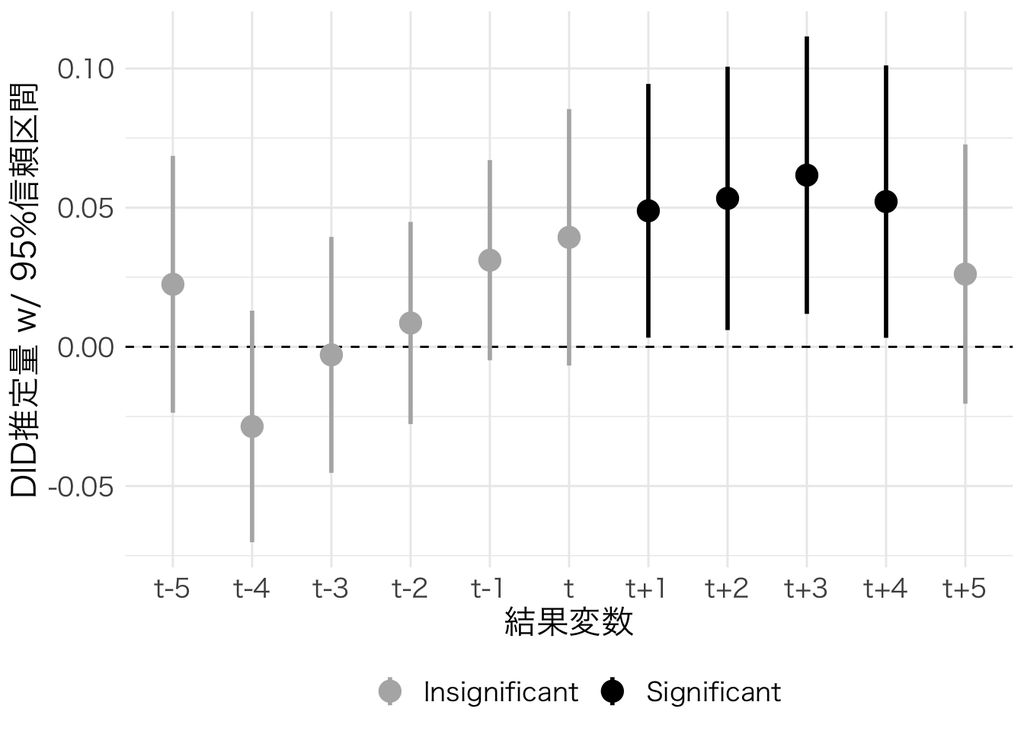

```r
Robust.Coef %>%
  ggplot() +
  # y = 0の水平線 (破線)
  geom_hline(yintercept = 0, linetype = 2) +
  # 各モデルの点推定値と信頼区間を出力
  # Sigの値によって色分け
  geom_pointrange(aes(x = Model, y = Coef, ymin = LL, ymax = UL,
                      color = Sig),
                  size = 1) +
  # 軸ラベルを設定
  labs(x = "結果変数", y = "DID推定量 w/ 95%信頼区間", color = "") +
  # 色分けを手動で調整
  scale_color_manual(values = c("Significant"   = "black",
                                "Insignificant" = "gray70")) +
  # 日本語フォントの指定
  theme_minimal(base_family = "HiraKakuProN-W3") +
  # 文字サイズ、凡例位置調整
  theme(text = element_text(size = 16),
        legend.position = "bottom")
```

Fouirnaies and Mutlu-Eren (2015)のFigure 3に比べると結果が若干異なります。なぜなら、Fouirnaies and Mutlu-Eren (2015)で推定したモデルとここで行った分析のモデルが一致しないからです。ここでは投入しなかった人口や選挙サイクルのダミー変数がFouirnaies and Mutlu-Eren (2015)では投入されています。また、ここで提供しているデータはFouirnaies and Mutlu-Eren (2015)と同じやり方でクリーニングされていない点も一つの原因です。それでもFouirnaies and Mutlu-Eren (2015)のFigure 3の非常に似たような結果が得られました。興味のある方は著者たちが提供している再現用データセットをダウンロードし、取り組んでみましょう。

# Synthetic Control Method

## `Synth`パッケージの使い方

それでは、差分の差分法の応用としてSynthetic Control Method (SCM) とCausalImpactについて解説します。ここではパッケージの使い方に重点を起きながら説明します。

まずは、SCMからです。`Synth`パッケージと実習用データを読み込みましょう。こちらはAbadie et al. (2015)[^7]のリプリケーションデータをcsvに変換したものとなります。

```r
library(Synth)
# read_csvでなく、read.csvを使用
# R 4.0.0未満の場合、stringsAsFactors = FALSEを付けること
Synth_Data <- read.csv("Day3_Data3.csv")
```

データの中身を確認してみましょう。

```r
DT::datatable(Synth_Data)
```

|  | index | country | year | gdp | infrate | trade | schooling | invest60 | invest70 | invest80 | industry |
| --- | --- | --- | --- | --- | --- | --- | --- | --- | --- | --- | --- |
| 1 | 1 | USA | 1960 | 2879 |  | 9.693181 | 43.8 |  |  |  |  |
| 2 | 1 | USA | 1961 | 2929 | 1.075182 | 9.444654 |  |  |  |  |  |
| 3 | 1 | USA | 1962 | 3103 | 1.116071 | 9.429324 |  |  |  |  |  |
| 4 | 1 | USA | 1963 | 3227 | 1.214128 | 9.470706 |  |  |  |  |  |
| 5 | 1 | USA | 1964 | 3420 | 1.308615 | 9.725879 |  |  |  |  |  |
| 6 | 1 | USA | 1965 | 3667 | 1.668461 | 9.730347 | 43.8 |  |  |  |  |
| 7 | 1 | USA | 1966 | 3974 | 2.991 | 10.097592 |  |  |  |  |  |
| 8 | 1 | USA | 1967 | 4154 | 2.775636 | 10.208102 |  |  |  |  |  |
| 9 | 1 | USA | 1968 | 4494 | 4.217721 | 10.593937 |  |  |  |  |  |
| 10 | 1 | USA | 1969 | 4805 | 5.414701 | 10.635633 |  |  |  |  |  |

[output cut: 738 more lines]

データの詳細はAbadie et al. (2015)の本文中付録を参照してください。ここで必要なものは以下の変数です。

| 変数 | 説明 |
| --- | --- |
| `index` | 国ID |
| `country` | 国名 |
| `year` | 年 |
| `gdp` | 一人当たりGDP |
| `infrate` | インフレーション率 |
| `trade` | 貿易依存度 |
| `schooling` | 25歳以上で中等教育以上修了者の割合 |
| `invest70` | 国内総投資の割合 |
| `industry` | 高付加価値産業のシェア |

まずは、可視化をしてみましょう。横軸は年、縦軸は一人当たりGDPです。西ドイツ以外の国は平均を計算し、一本の線としてまとめます。また、ドイツが統一した1990年に垂直線を引きます。

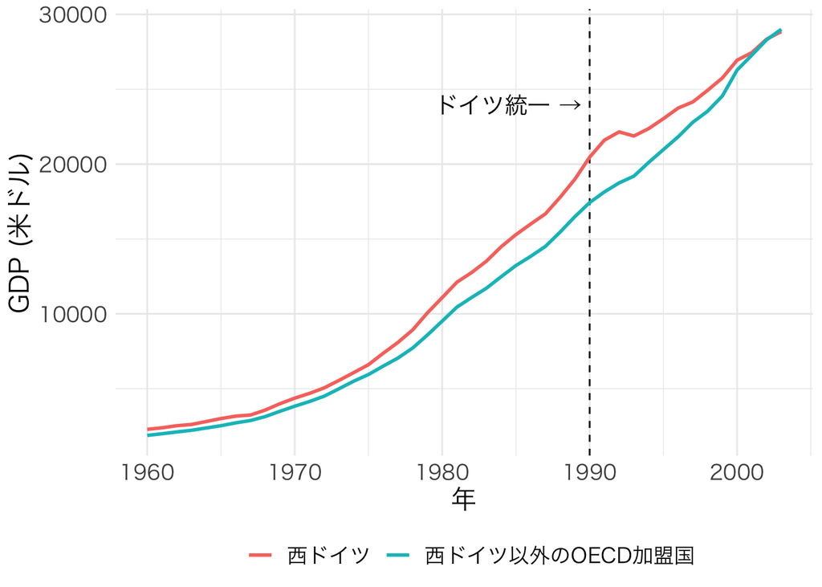

```r
#quartz(type = "pdf", file = "../Figs/SCM2.pdf", width = 8, height = 4)
Synth_Data %>%
  mutate(WG = if_else(country == "West Germany",
                      "西ドイツ", "西ドイツ以外のOECD加盟国")) %>%
  group_by(WG, year) %>%
  summarise(GDP     = mean(gdp),
            .groups = "drop") %>%
  ggplot() +
  geom_vline(xintercept = 1990, linetype = 2) +
  geom_line(aes(x = year, y = GDP, color = WG), size = 1) +
  annotate("text", x = 1990, y = 24000, label = "ドイツ統一 → ",
           hjust = 1, family = "HiraKakuProN-W3", size = 5) +
  labs(x = "年", y = "GDP (米ドル)",
       color = "", linetype = "") +
  theme_minimal(base_family = "HiraKakuProN-W3") +
  theme(legend.position = "bottom",
        text = element_text(size = 16))
```

```r
#dev.off()
```

赤い線が西ドイツ、青がその他のOECD加盟国の平均GDPです。全体的な傾向は同じですが、80年代以降はトレンドが並行するというよりも、どんどん拡大しているように見えます。

それでは、SCMの実装について説明します。`Synth`パッケージのメインは、データの準備に使う`dataprep()`とSMCの推定に使う`synth()`です。`snyth()`は比較的に使いやすいですが、問題は`dataprep()`です。ここでは、個々のパラメーターについて詳細に解説するより、コードの解説を中心に進めます。

```r
Train_Data <- dataprep(
  # データを指定
  foo           = Synth_Data,
  # トレンドを予測する際に使用する共変量を指定
  # ここではgdp, infrate, tradeを使います
  predictors    = c("gdp", "infrate", "trade"),
  # 結果変数を指定
  dependent     = "gdp",
  # 観察対象を指定
  # ここではindexとcountry列がありますが、ここはnumeric型である必要があり、
  # indexを指定します。countryは後ほど使います
  unit.variable = "index",
  # 時間を表す変数を指定
  time.variable = "year",
  # ここではやや特殊な共変量を指定します
  # たとえば、1971年から1980年までのindustryの平均値などです
  special.predictors = list(
    list("industry",  1971:1980,    c("mean")),
    list("schooling", c(1970,1975), c("mean")),
    list("invest70",  1980,         c("mean"))
  ),
  # 処置変数を受ける観察対象の番号を指定します
  # West Germanyのindex番号は7です
  treatment.identifier  = 7,
  # 処置群以外の観察対象の番号を指定します
  controls.identifier   = unique(Synth_Data$index)[-7],
  # 処置前の期間を指定します
  # year変数が1971から1980までの場合を処置前とします（後で説明）
  time.predictors.prior = 1971:1980,
  # 損失関数を最小化する範囲を指定します
  # 基本的には処置前の任意の時点〜処置を受ける時点に設定します
  # ここでは処置前の10年分とします
  time.optimize.ssr     = 1981:1990,
  # 国名が格納されている列名を指定します
  unit.names.variable   = "country",
  # 可視化の際、横軸の範囲を指定します
  time.plot             = 1960:2003
  )
```

非常に使いにくい関数ですが、それでも自分で直接SCMを実装するよりは遥かに楽です。SCMを行う前に、いくつか説明をしておきます。

まず、`time.predictors.prior`引数ですが、ここでは`1971:1980`に指定しました。「ドイツ統一は1990年だから`1971:1990`にすべきでは？」と思うのが普通でしょう。それが正しいです。ただし、`synth()`関数を使う場合はいくつかのパラメーターを指定する必要があり、それは`synth()`関数が自動的に指定してくれます。しかし、データを100%使ってそのパラメーターを決める場合、過適合（overfitting）が生じる可能性があります。まずは、架空の西ドイツを作るのが目的であるため、ここでは全期間でなく、処置前の一部の期間のみで架空の西ドイツを作成し、そこから得られたパラメーターをもう一回使います。だから、ここではまず1971年から1980年までのデータを使います。

それではSCMを行います。先ほど`dataprep()`から作成したオブジェクトを`synth()`関数に渡すわけです。

```r
Train_Fit <- synth(Train_Data)
```

```
##
## X1, X0, Z1, Z0 all come directly from dataprep object.
##
##
## ****************
##  searching for synthetic control unit
##
##
## ****************
## ****************
## ****************
##
## MSPE (LOSS V): 4556.721
##
## solution.v:
##  0.5598212 0.04804541 0.099915 0.004093611 0.07931743 0.2088073
##
## solution.w:
##  0.132081 5.52698e-05 0.5028072 3.72175e-05 0.0001515816 4.09008e-05 3.65981e-05 0.00012152 3.73332e-05 0.1693102 0.1488914 2.72698e-05 2.61162e-05 2.71489e-05 0.04555833 0.0007909723
```

ここまでの結果を見ることもできますが、先が長いのでとりあえず、本分析に入ります。まずは、本分析のためのデータを用意します。

```r
Main_Data <- dataprep(
  foo           = Synth_Data,
  predictors    = c("gdp","trade","infrate"),
  dependent     = "gdp",
  unit.variable = "index",
  time.variable = "year",
  special.predictors = list(
    list("industry",  1981:1990,    c("mean")), # <<
    list("schooling", c(1980,1985), c("mean")), # <<
    list("invest80",  1980,         c("mean"))  # <<
  ),
  treatment.identifier  = 7,
  controls.identifier   = unique(Synth_Data$index)[-7],
  time.predictors.prior = 1981:1990, # <<
  time.optimize.ssr     = 1960:1989, # <<
  unit.names.variable   = "country",
  time.plot             = 1960:2003
  )
```

```
##
##  Missing data: treated unit; special predictor: special.industry.1981.1990 ; for period: 1990
##  We ignore (na.rm = TRUE) all missing values for predictors.op.
```

SCMに使うデータの期間が変わるため、いくつかの行を修正する必要があります。それではSCMを行います。ここではvパラメーターを直接指定します。`custom.v = as.numeric(Train_Fit$solution.v)`を指定すると、`Train_Fit`で決められたvパラメーターを本分析のモデルで使うことができます。

```r
Main_Fit <- synth(Main_Data,
                  custom.v = as.numeric(Train_Fit$solution.v))
```

```
##
## X1, X0, Z1, Z0 all come directly from dataprep object.
##
##
## ****************
##  optimization over w weights: computing synthtic control unit
##
##
##
## ****************
##  v weights supplied manually: computing synthtic control unit
##
##
##
## ****************
## ****************
## ****************
##
## MSPE (LOSS V): 14035.22
##
## solution.v:
##  0.5598212 0.04804541 0.099915 0.004093611 0.07931743 0.2088073
##
## solution.w:
##  0.2159589 5.2323e-06 0.4017819 1.05206e-05 8.1855e-06 6.9831e-06 4.1299e-06 0.1073192 5.4163e-06 0.1134424 0.1614399 2.2224e-06 2.4139e-06 4.2491e-06 4.7768e-06 3.5972e-06
```

可視化の前に、バランスチェックと各国の重みを計算してみましょう。ここでは`synth.tab()`関数を使います。必要な引数はSCMに使用したデータ（`dataprep.res =`）、SCM推定結果（`synth.res =`）の2つです。

```r
Synth_Table <- synth.tab(dataprep.res = Main_Data,
                         synth.res    = Main_Fit)

Synth_Table
```

```
## $tab.pred
##                               Treated Synthetic Sample Mean
## gdp                         15808.900 15801.364   13669.381
## trade                          56.778    57.346      59.831
## infrate                         2.595     3.434       7.617
## special.industry.1981.1990     34.538    34.385      33.794
## special.schooling.1980.1985    55.500    54.949      38.659
## special.invest80.1980          27.018    27.043      25.895
##
## $tab.v
##                             v.weights
## gdp                             0.560
## trade                           0.048
## infrate                         0.100
## special.industry.1981.1990      0.004
## special.schooling.1980.1985     0.079
## special.invest80.1980           0.209
##
## $tab.w
##    w.weights  unit.names unit.numbers
## 1      0.216         USA            1
## 2      0.000          UK            2
## 3      0.402     Austria            3
## 4      0.000     Belgium            4
## 5      0.000     Denmark            5
## 6      0.000      France            6
## 8      0.000       Italy            8
## 9      0.107 Netherlands            9
## 10     0.000      Norway           10
## 12     0.113 Switzerland           12
## 14     0.161       Japan           14
## 16     0.000      Greece           16
## 18     0.000    Portugal           18
## 19     0.000       Spain           19
## 20     0.000   Australia           20
## 21     0.000 New Zealand           21
##
## $tab.loss
##           Loss W   Loss V
## [1,] 0.003111837 14035.22
```

論文で主に使うのは`$tab.pred`と`$tab.w`です。

続いてSCMでよく見る図を可視化してみましょう。まずは`path.plot()`を使って、架空西ドイツと西ドイツのGDPの変化を確認してみましょう。

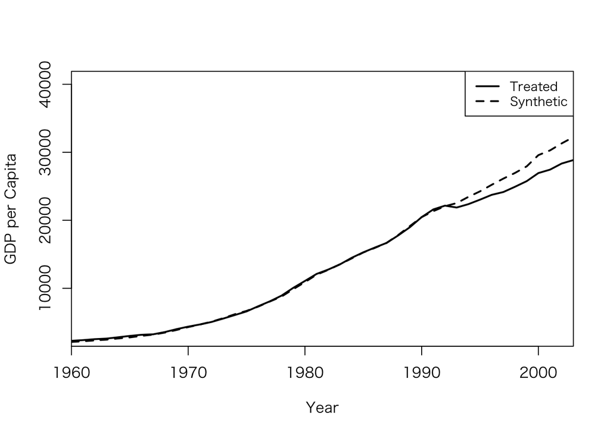

```r
path.plot(synth.res    = Main_Fit,
          dataprep.res = Main_Data,
          Xlab = "Year", Ylab = "GDP per Capita")
```

これを`ggplot2`で作図する場合、以下のようなコードになります。

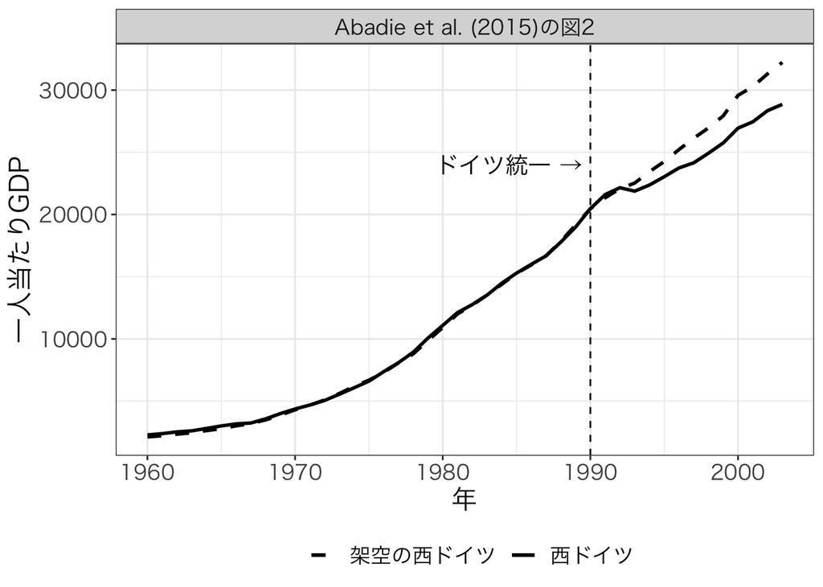

```r
Synth_Result <- data.frame(
  Year = 1960:2003,
  WG   = Main_Data$Y1plot[, 1],
  C_WG = (Main_Data$Y0 %*% Main_Fit$solution.w)[, 1]
  )

Path_Plot <- Synth_Result %>%
  ggplot(aes(x = Year)) +
  geom_vline(xintercept = 1990, linetype = 2) +
  geom_line(aes(y = WG, linetype = "西ドイツ"), size = 1) +
  geom_line(aes(y = C_WG, linetype = "架空の西ドイツ"), size = 1) +
  annotate("text", x = 1990, y = 24000, label = "ドイツ統一 → ",
           hjust = 1, family = "HiraKakuProN-W3", size = 5) +
  scale_linetype_manual(values = c("西ドイツ"       = 1,
                                   "架空の西ドイツ" = 2)) +
  labs(x = "年", y = "一人当たりGDP",
       color = "", linetype = "") +
  theme_bw(base_family = "HiraKakuProN-W3") +
  facet_wrap(~"Abadie et al. (2015)の図2") +
  theme(legend.position = "bottom",
        text = element_text(size = 16))

Path_Plot
```

`gaps.plot()`は架空の西ドイツと実際のドイツ間のGDPの差分を示したものです。

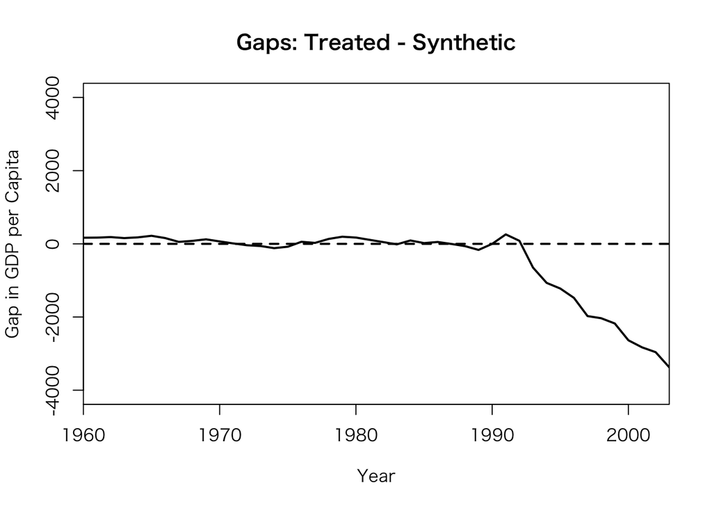

```r
gaps.plot(synth.res    = Main_Fit,
          dataprep.res = Main_Data,
          Xlab = "Year", Ylab = "Gap in GDP per Capita")
```

`ggplot2`を使うと以下のようなコードになります。

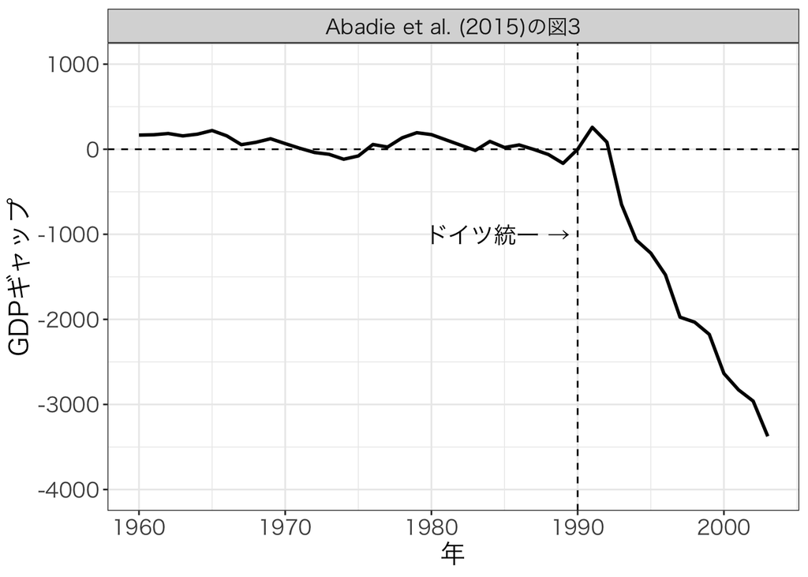

```r
Gaps_Plot <- Synth_Result %>%
  mutate(Gap = WG - C_WG) %>%
  ggplot(aes(x = Year, y = Gap)) +
  geom_vline(xintercept = 1990, linetype = 2) +
  geom_hline(yintercept = 0,    linetype = 2) +
  geom_line(size = 1) +
  annotate("text", x = 1990, y = -1000, label = "ドイツ統一 → ",
           hjust = 1, family = "HiraKakuProN-W3", size = 5) +
  labs(x = "年", y = "GDPギャップ",
       color = "", linetype = "") +
  coord_cartesian(ylim = c(-4000, 1000)) +
  theme_bw(base_family = "HiraKakuProN-W3") +
  facet_wrap(~"Abadie et al. (2015)の図3") +
  theme(legend.position = "bottom",
        text = element_text(size = 16))

Gaps_Plot
```

# CausalImpact

最後にCausalImpactの実装方法について解説します。必要なパッケージは`CaucalImpact`のみです。事前に`install.packages("CausalImpact")`を実行し、パッケージをインストールしてください。

## `CausalImpact`パッケージの使い方

まずは`CausalImpact`パッケージと実習用データを読み込みます。実習用データは[担当教員のホームページ](https://www.jaysong.net/post/kobe2020-qpm1/)、または授業用Slackからダウンロードできます。

```r
library(CausalImpact)

# 実習用データの読み込み
Stock_Data <- read_csv("Day3_Data4.csv")
```

データの中身を確認します。`DT`パッケージの`datatable()`関数を使用します。

```r
DT::datatable(Stock_Data)
```

|  | Date | Time | Trend | Stock_J | Stock_K |
| --- | --- | --- | --- | --- | --- |
| 1 | 20/08/28 | 13:00:00 | 1 | 23340 | 23700 |
| 2 | 20/08/28 | 13:01:00 | 2 | 23330 | 23690 |
| 3 | 20/08/28 | 13:02:00 | 3 | 23330 | 23705 |
| 4 | 20/08/28 | 13:03:00 | 4 | 23330 | 23705 |
| 5 | 20/08/28 | 13:04:00 | 5 | 23330 | 23705 |
| 6 | 20/08/28 | 13:05:00 | 6 | 23340 | 23690 |
| 7 | 20/08/28 | 13:06:00 | 7 | 23340 | 23685 |
| 8 | 20/08/28 | 13:07:00 | 8 | 23340 | 23705 |
| 9 | 20/08/28 | 13:08:00 | 9 | 23320 | 23685 |
| 10 | 20/08/28 | 13:09:00 | 10 | 23320 | 23675 |

[output cut: 111 more lines]

| 変数名 | 説明 |
| --- | --- |
| `Date` | 日付 |
| `Time` | 時間 (一分単位) |
| `Trend` | トレンド変数。13時を1とし、1分毎に1増えます |
| `Stock_J` | 株価（日本） |
| `Stock_K` | 株価（韓国） |

NHKから正確な報道時間は不明ですが、14時6分頃だったような気がします。データから14時6分の`Trend`値を確認しておいてください。まずは、株価の推移を可視化してみましょう。横軸は`Trend`、縦軸は`Stock_J`にした折れ線グラフを作成します。また、14時6分（`Treat == 67`）に垂直線を追加すると、NHK報道の前後比較がしやすくなります。

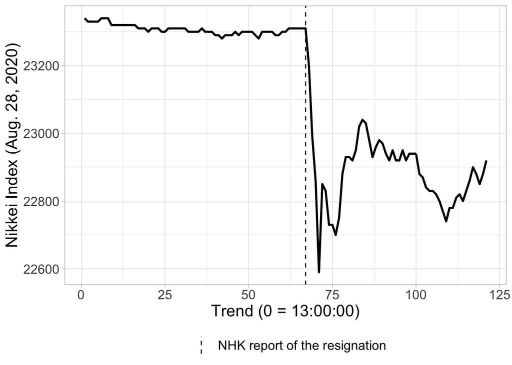

```r
Stock_Data %>%
  ggplot() +
  geom_vline(aes(xintercept = 67,
                 linetype = 'NHK report of the resignation')) +
  geom_line(aes(x = Trend, y = Stock_J), size = 1) +
  labs(x = "Trend (0 = 13:00:00)", y = "Nikkei Index (Aug. 28, 2020)",
       color = "", linetype = "") +
  scale_linetype_manual(values = c('NHK report of the resignation' = 2)) +
  theme_light() +
  theme(legend.position = "bottom",
        text            = element_text(size = 16))
```

報道直後において株価が急落したことが分かります。それでは、CausalImpact推定を行います。使う関数は`CausalImpact()`関数であり、必須引数は`data`、`pre.period`、`post.period`の3つです。他にも引数はいくつかありますが、詳細は`?CausalImpact`から確認してください。

`data`引数は第一引数であり、ベクトル、またはデータフレーム（tibble）型を指定します。こちらは株価のデータを指定します。`data = Stock_Data$Stock_J`でも良いですし、`Stock_Data`から`Stock_J`列のみ抽出し、これをパイプ（`%>%`）で`CausalImpact()`へ渡すことも可能です。ここでは後者の方法を採用します。

続いて、`pre.period`と`post.period`引数ですが、こちらは長さ2の数値型ベクトルを指定します。`pre.period = c(1, 67)`なら`data`の1番目から67番目の要素は処置前の期間であることを意味し、`post.period = c(68, 121)`は68番目から121番目の要素が処置後の期間であることを意味します。

```r
CI_wo_Cov <- Stock_Data %>%
  dplyr::select(Stock_J) %>%
  CausalImpact(pre.period  = c(1, 67),
               post.period = c(68, 121))
```

結果を確認するには`summary()`関数を使います。

```r
summary(CI_wo_Cov)
```

```
## Posterior inference {CausalImpact}
##
##                          Average          Cumulative
## Actual                   22881            1235580
## Prediction (s.d.)        23307 (2.7)      1258595 (146.9)
## 95% CI                   [23302, 23313]   [1258314, 1258886]
##
## Absolute effect (s.d.)   -426 (2.7)       -23015 (146.9)
## 95% CI                   [-432, -421]     [-23306, -22734]
##
## Relative effect (s.d.)   -1.8% (0.012%)   -1.8% (0.012%)
## 95% CI                   [-1.9%, -1.8%]   [-1.9%, -1.8%]
##
## Posterior tail-area probability p:   0.00102
## Posterior prob. of a causal effect:  99.89796%
##
## For more details, type: summary(impact, "report")
```

`Absolute effect`行の`Average`列を見ると-426 (2.7)という結果が得られています。これはNHKの報道によって株価が約426ポイント下がったことを意味します。これは処置後期間における差分の平均値となります。`Cumulateve`列は差分の累積となります。他にも`Relative effect`列から株価が何%下がったらかが確認できます。

これらの結果を可視化するには`plot()`関数を使います。

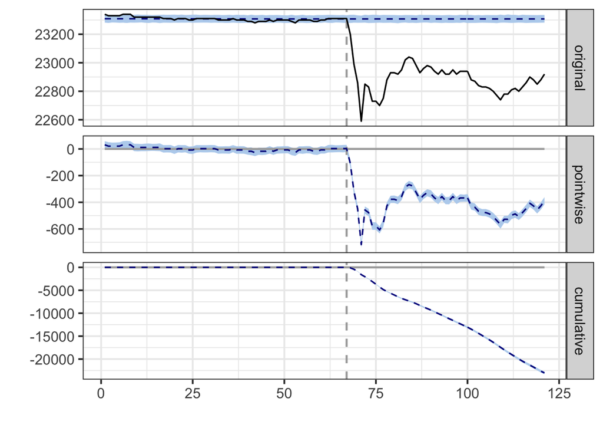

```r
plot(CI_wo_Cov)
```

## 共変量の追加

つづいて、共変量を追加する簡単な例を紹介します。ここでは同じ時間帯を共有し、株価の変動がかなり似ている韓国の株価を使います。まずはトレンドを確認してみましょう。韓国の株価は`Stock_K`列に入っています。

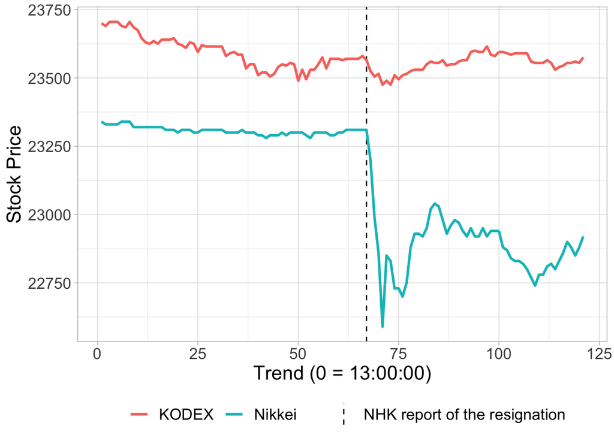

```r
Stock_Data %>%
  ggplot() +
  geom_vline(aes(xintercept = 67,
                 linetype = 'NHK report of the resignation')) +
  geom_line(aes(x = Trend, y = Stock_J, color = "Nikkei"), size = 1) +
  geom_line(aes(x = Trend, y = Stock_K, color = "KODEX"), size = 1) +
  labs(x = "Trend (0 = 13:00:00)", y = "Stock Price",
       color = "", linetype = "") +
  scale_linetype_manual(values = c('NHK report of the resignation' = 2)) +
  theme_light() +
  theme(legend.position = "bottom",
        text            = element_text(size = 16))
```

韓国も日本と同じタイミングで株価が多少下落しましたが、全体的には安定しているように見えます。それでは、韓国の株価を追加し、架空の株価を作成してみましょう。共変量の追加は`data`引数のデータフレームに`Stock_K`列を加えるだけです。第1列は予測の対象となり、第2列以降は共変量です。したがって、1列目は`Stock_J`、2列目は`Stock_K`になるようにします。

推定が終わったら結果を確認してみましょう。

```r
CI_w_Cov <- Stock_Data %>%
  dplyr::select(Stock_J, Stock_K) %>%
  CausalImpact(pre.period  = c(1, 67),
               post.period = c(68, 121))

summary(CI_w_Cov)
```

```
## Posterior inference {CausalImpact}
##
##                          Average           Cumulative
## Actual                   22881             1235580
## Prediction (s.d.)        23299 (1.6)       1258139 (89.0)
## 95% CI                   [23296, 23302]    [1257962, 1258311]
##
## Absolute effect (s.d.)   -418 (1.6)        -22559 (89.0)
## 95% CI                   [-421, -414]      [-22731, -22382]
##
## Relative effect (s.d.)   -1.8% (0.0071%)   -1.8% (0.0071%)
## 95% CI                   [-1.8%, -1.8%]    [-1.8%, -1.8%]
##
## Posterior tail-area probability p:   0.00127
## Posterior prob. of a causal effect:  99.87261%
##
## For more details, type: summary(impact, "report")
```

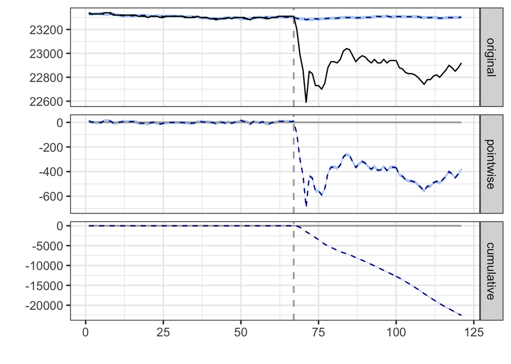

```r
plot(CI_w_Cov)
```

[^1]: `pacman`パッケージの`p_load()`はパッケージがインストールされていない場合はインストール後、自動的に読み込んでくれます。インストール済みの場合はパッケージを読み込むだけですので、非常に便利なパッケージです。
[^2]: [Alexander Fouirnaies and Hande Mutlu-Eren. 2015. “English Bacon: Copartisan Bias in Intergovernmental Grant Allocation in England.” *Journal of Politics,* 77 (3): 805-817](https://www.journals.uchicago.edu/doi/abs/10.1086/681563)
[^3]: 今回の例だと、地方議会ダミー変数です。
[^4]: リストの中にリストを入れることも可能です。
[^5]: 近年、標準になりつつある`tibble`型はここでは使いません。なぜならtibble型だと、`データ[1, 2:3] <- c(1, 2)`のような置換ができないからです。
[^6]: 他にも論文では人口 (対数)、選挙年ダミーも含まれていますが、ここでは省略します。
[^7]: Abadie, Alberto, Alexis Diamond, and Jens Hainmueller. 2015. “Comparative Politics and the Synthetic Control Method.” *American Journal of Political Science,* 59 (2): 495–510.